# ADVANCED ANALYST - Foundations for Advanced Data Analytics in R - Session03

Goran S. Milovanović, PhD

DataKolektiv, Chief Scientist & Owner; Lead Data Scientist for smartocto

# Module 2: Data Visualization and Exploratory Analytics

## Week 03: Basics of ggplot2: The Grammar of Graphics

**Feedback** should be send to `goran.milovanovic@datakolektiv.com`. These notebooks accompany the ADVANCED ANALYST - Foundations for Advanced Data Analytics in R [DataKolektiv](http://www.datakolektiv.com/app_direct/DataKolektivServer/) training.

### Welcome to R!

### What do we want to do today?

Our task in this session is to learn the basics of the powerful [ggplot2](https://ggplot2.tidyverse.org/) package, the industry standard in *data visualization*. Instead of learning visualization just to learn ggplot2, we will set ourselves a narrative: namely, right from the start, through visualization, we will actually conduct a minimal EDA - which stands for **Exploratory Data Analysis**. The EDA step is something that practically begins every serious statistical analysis of a dataset and serves to allow the analyst to make the first, important, and preliminary conclusions about the data in front of them, before starting to use more powerful analytical tools of statistical modeling and machine learning. Data visualization plays a huge role in these steps.

### 1. The data set at hand: `flights`

We have already used the `flights` data set: it is part of a broader set of data that we can obtain from the well-known R package [nycflights13: Flights that Departed NYC in 2013](https://cran.r-project.org/web/packages/nycflights13/index.html).

```r
# Load the tidyverse package: ggplot2 is a part of it!
library(tidyverse)
# The path to your CSV file
data_dir <- paste0(getwd(), "/_data/")
filename <- "flights.csv"
filepath <- paste0(data_dir, filename)

# Load the data into R
flights <- readr::read_csv(filepath)
# Remove the index column
flights$...1 <- NULL

# Glimpse its structure to ensure it has arrived in full
glimpse(flights)
```

```
Rows: 336,776
Columns: 19
$ year           <dbl> 2013, 2013, 2013, 2013, 2013, 2013, 2013, 2013, 2013, 2013, 2013, 2013, 2013, 2013, 2013, 201…
$ month          <dbl> 1, 1, 1, 1, 1, 1, 1, 1, 1, 1, 1, 1, 1, 1, 1, 1, 1, 1, 1, 1, 1, 1, 1, 1, 1, 1, 1, 1, 1, 1, 1, …
$ day            <dbl> 1, 1, 1, 1, 1, 1, 1, 1, 1, 1, 1, 1, 1, 1, 1, 1, 1, 1, 1, 1, 1, 1, 1, 1, 1, 1, 1, 1, 1, 1, 1, …
$ dep_time       <dbl> 517, 533, 542, 544, 554, 554, 555, 557, 557, 558, 558, 558, 558, 558, 559, 559, 559, 600, 600…
$ sched_dep_time <dbl> 515, 529, 540, 545, 600, 558, 600, 600, 600, 600, 600, 600, 600, 600, 600, 559, 600, 600, 600…
$ dep_delay      <dbl> 2, 4, 2, -1, -6, -4, -5, -3, -3, -2, -2, -2, -2, -2, -1, 0, -1, 0, 0, 1, -8, -3, -4, -4, 0, 8…
$ arr_time       <dbl> 830, 850, 923, 1004, 812, 740, 913, 709, 838, 753, 849, 853, 924, 923, 941, 702, 854, 851, 83…
$ sched_arr_time <dbl> 819, 830, 850, 1022, 837, 728, 854, 723, 846, 745, 851, 856, 917, 937, 910, 706, 902, 858, 82…
$ arr_delay      <dbl> 11, 20, 33, -18, -25, 12, 19, -14, -8, 8, -2, -3, 7, -14, 31, -4, -8, -7, 12, -6, -8, 16, -12…
$ carrier        <chr> "UA", "UA", "AA", "B6", "DL", "UA", "B6", "EV", "B6", "AA", "B6", "B6", "UA", "UA", "AA", "B6…
$ flight         <dbl> 1545, 1714, 1141, 725, 461, 1696, 507, 5708, 79, 301, 49, 71, 194, 1124, 707, 1806, 1187, 371…
$ tailnum        <chr> "N14228", "N24211", "N619AA", "N804JB", "N668DN", "N39463", "N516JB", "N829AS", "N593JB", "N3…
$ origin         <chr> "EWR", "LGA", "JFK", "JFK", "LGA", "EWR", "EWR", "LGA", "JFK", "LGA", "JFK", "JFK", "JFK", "E…
$ dest           <chr> "IAH", "IAH", "MIA", "BQN", "ATL", "ORD", "FLL", "IAD", "MCO", "ORD", "PBI", "TPA", "LAX", "S…
$ air_time       <dbl> 227, 227, 160, 183, 116, 150, 158, 53, 140, 138, 149, 158, 345, 361, 257, 44, 337, 152, 134, …
$ distance       <dbl> 1400, 1416, 1089, 1576, 762, 719, 1065, 229, 944, 733, 1028, 1005, 2475, 2565, 1389, 187, 222…
$ hour           <dbl> 5, 5, 5, 5, 6, 5, 6, 6, 6, 6, 6, 6, 6, 6, 6, 5, 6, 6, 6, 6, 6, 6, 6, 6, 6, 6, 6, 6, 6, 6, 6, …
$ minute         <dbl> 15, 29, 40, 45, 0, 58, 0, 0, 0, 0, 0, 0, 0, 0, 0, 59, 0, 0, 0, 0, 10, 5, 10, 10, 7, 0, 0, 10,…
$ time_hour      <dttm> 2013-01-01 05:00:00, 2013-01-01 05:00:00, 2013-01-01 05:00:00, 2013-01-01 05:00:00, 2013-01-…
```

### 2. Descriptive Statistics

Descriptive statistics summarize and provide information about your data. Common measures include mean, median, mode (for central tendency), standard deviation, and quartiles (for variability).

Example in R:

```r
# Summary of the dataset
summary(flights)
```

```
      year          month             day           dep_time    sched_dep_time   dep_delay          arr_time
 Min.   :2013   Min.   : 1.000   Min.   : 1.00   Min.   :   1   Min.   : 106   Min.   : -43.00   Min.   :   1
 1st Qu.:2013   1st Qu.: 4.000   1st Qu.: 8.00   1st Qu.: 907   1st Qu.: 906   1st Qu.:  -5.00   1st Qu.:1104
 Median :2013   Median : 7.000   Median :16.00   Median :1401   Median :1359   Median :  -2.00   Median :1535
 Mean   :2013   Mean   : 6.549   Mean   :15.71   Mean   :1349   Mean   :1344   Mean   :  12.64   Mean   :1502
 3rd Qu.:2013   3rd Qu.:10.000   3rd Qu.:23.00   3rd Qu.:1744   3rd Qu.:1729   3rd Qu.:  11.00   3rd Qu.:1940
 Max.   :2013   Max.   :12.000   Max.   :31.00   Max.   :2400   Max.   :2359   Max.   :1301.00   Max.   :2400
                                                 NA's   :8255                  NA's   :8255      NA's   :8713
 sched_arr_time   arr_delay          carrier              flight       tailnum             origin
 Min.   :   1   Min.   : -86.000   Length:336776      Min.   :   1   Length:336776      Length:336776
 1st Qu.:1124   1st Qu.: -17.000   Class :character   1st Qu.: 553   Class :character   Class :character
 Median :1556   Median :  -5.000   Mode  :character   Median :1496   Mode  :character   Mode  :character
 Mean   :1536   Mean   :   6.895                      Mean   :1972
 3rd Qu.:1945   3rd Qu.:  14.000                      3rd Qu.:3465
 Max.   :2359   Max.   :1272.000                      Max.   :8500
                NA's   :9430
     dest              air_time        distance         hour           minute        time_hour
 Length:336776      Min.   : 20.0   Min.   :  17   Min.   : 1.00   Min.   : 0.00   Min.   :2013-01-01 05:00:00.00
 Class :character   1st Qu.: 82.0   1st Qu.: 502   1st Qu.: 9.00   1st Qu.: 8.00   1st Qu.:2013-04-04 13:00:00.00
 Mode  :character   Median :129.0   Median : 872   Median :13.00   Median :29.00   Median :2013-07-03 10:00:00.00
                    Mean   :150.7   Mean   :1040   Mean   :13.18   Mean   :26.23   Mean   :2013-07-03 05:02:36.49
                    3rd Qu.:192.0   3rd Qu.:1389   3rd Qu.:17.00   3rd Qu.:44.00   3rd Qu.:2013-10-01 07:00:00.00
                    Max.   :695.0   Max.   :4983   Max.   :23.00   Max.   :59.00   Max.   :2013-12-31 23:00:00.00
                    NA's   :9430
```

Calculate mean and median for a numeric column, e.g., `distance`:

```r
mean(flights$distance)
```

```
[1] 1039.913
```

```r
median(flights$distance)
```

```
[1] 872
```

The frequency distribution of a variable, e.g. `carrier`:

```r
table(flights$carrier)
```

```
   9E    AA    AS    B6    DL    EV    F9    FL    HA    MQ    OO    UA    US    VX    WN    YV
18460 32729   714 54635 48110 54173   685  3260   342 26397    32 58665 20536  5162 12275   601
```

Frequency table as a data.frame:

```r
carriers <- as.data.frame(table(flights$carrier))
head(carriers)
```

|  | Var1 | Freq |
| --- | --- | --- |
| 1 | 9E | 18460 |
| 2 | AA | 32729 |
| 3 | AS | 714 |
| 4 | B6 | 54635 |
| 5 | DL | 48110 |
| 6 | EV | 54173 |

Sort data.frame in R with `dplyr::arrange()`:

```r
carriers <- as.data.frame(table(flights$carrier))

# We will analyse the next line carefully:
carriers <- carriers |> dplyr::arrange(desc(Freq))

head(carriers, 10)
```

|  | Var1 | Freq |
| --- | --- | --- |
| 1 | UA | 58665 |
| 2 | B6 | 54635 |
| 3 | EV | 54173 |
| 4 | DL | 48110 |
| 5 | AA | 32729 |
| 6 | MQ | 26397 |
| 7 | US | 20536 |
| 8 | 9E | 18460 |
| 9 | WN | 12275 |
| 10 | VX | 5162 |

### 3. Introducing Outliers with `ggplot2::geom_boxplot()`

Outliers are data points that differ significantly from other observations. They can indicate variability in a measurement, experimental errors, or novelty.

Boxplot in ggplot2:

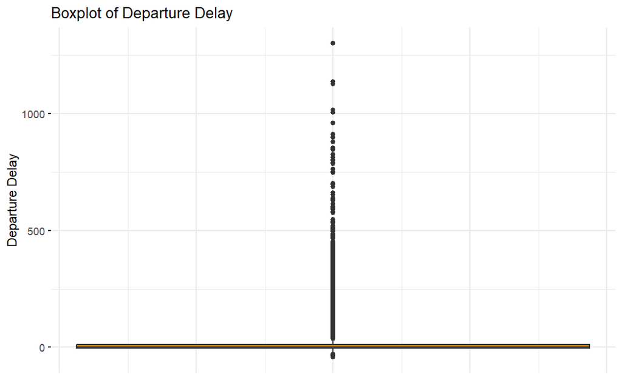

```r
# Assuming 'dep_delay' might have outliers
ggplot(flights,
       aes(y = dep_delay)) +
  geom_boxplot(fill = "darkorange") +
  labs(y = "Departure Delay") +
  ggtitle("Boxplot of Departure Delay") +
  theme_bw() +
  theme(panel.border = element_blank()) +
  theme(axis.ticks.x = element_blank()) +
  theme(axis.text.x = element_blank())
```

Hm, how many `NA` entries do we have in `flights$dep_delay`?

```r
sum(is.na(flights$dep_delay))
```

```
[1] 8255
```

Too much. I will keep only complete observations from `flights`:

```r
dim(flights)
```

```
[1] 336776     19
```

```r
flights <- flights[complete.cases(flights), ]
dim(flights)
```

```
[1] 327346     19
```

Let’s boxplot it now:

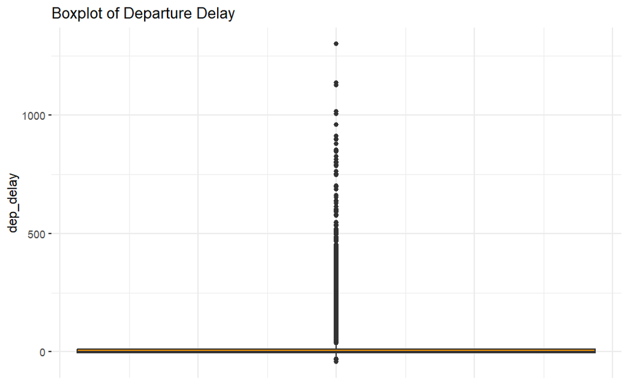

```r
ggplot(flights, aes(y = dep_delay)) +
  geom_boxplot(fill = "darkorange") +
  labs(y = "dep_delay") +
  ggtitle("Boxplot of Departure Delay") +
  theme_bw() +
  theme(panel.border = element_blank()) +
  theme(panel.border = element_blank()) +
  theme(axis.ticks.x = element_blank()) +
  theme(axis.text.x = element_blank())
```

A log scale, perhaps?

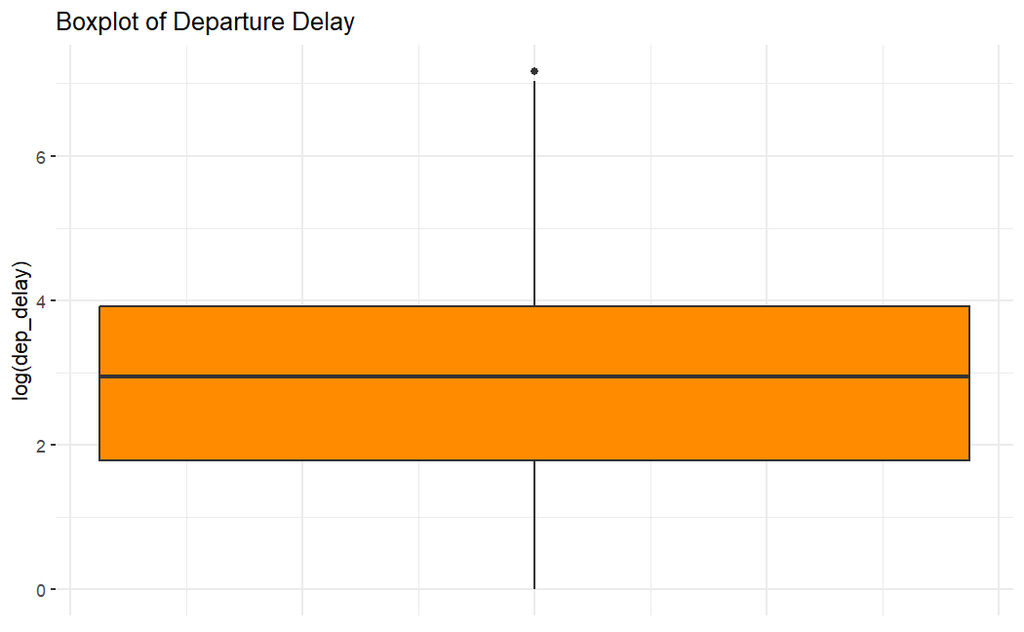

```r
ggplot(flights,
       aes(y = log(dep_delay))) +
  geom_boxplot(fill = "darkorange") +
  labs(y = "log(dep_delay)") +
  ggtitle("Boxplot of Departure Delay") +
  theme_bw() +
  theme(panel.border = element_blank()) +
  theme(panel.border = element_blank()) +
  theme(axis.ticks.x = element_blank()) +
  theme(axis.text.x = element_blank())
```

Let’s see…

```r
sum(flights$dep_delay <= 0)
```

```
[1] 199601
```

Ok, remove zero observations from `flights$dep_delay`:

```r
dim(flights)
```

```
[1] 327346     19
```

```r
flights <- flights[flights$dep_delay > 0, ]
dim(flights)
```

```
[1] 127745     19
```

Again:

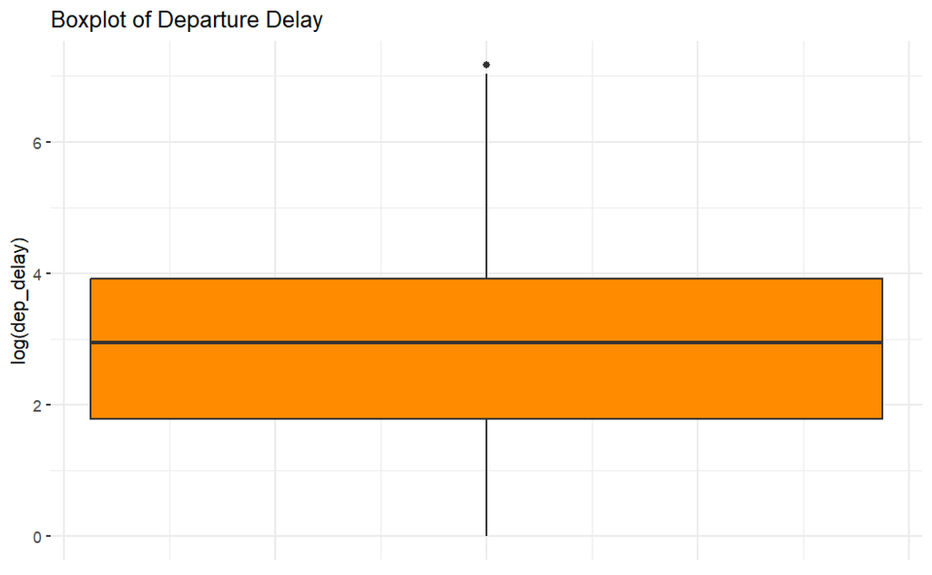

```r
ggplot(flights, aes(y = log(dep_delay))) +
  geom_boxplot(fill = "darkorange") +
  labs(y = "log(dep_delay)") +
  ggtitle("Boxplot of Departure Delay") +
  theme_bw() +
  theme(panel.border = element_blank()) +
  theme(panel.border = element_blank()) +
  theme(axis.ticks.x = element_blank()) +
  theme(axis.text.x = element_blank())
```

The definitions of the fences used in R in a boxplot are:

- Lower inner fence: Q1 - 1.5*IQR
- Upper inner fence: Q3 + 1.5*IQR
- Lower outer fence: Q1 - 3*IQR
- Upper outer fence: Q3 + 3*IQR
- A point beyond an inner fence on either side is considered a *mild outlier*.
- A point beyond an outer fence is considered an *extreme outlier*.

Wait, what is **IQR**?

```r
median(flights$dep_delay)
```

```
[1] 19
```

```r
# Q1: 25%
quantile(flights$dep_delay, .25)
```

```
25%
  6
```

```r
# Q3
quantile(flights$dep_delay, .75)
```

```
75%
 50
```

The median:

```r
# median
quantile(flights$dep_delay, .5)
```

```
50%
 19
```

IQR is the *Interquartile Range*:

```r
IQR <- quantile(flights$dep_delay, .75) - quantile(flights$dep_delay, .25)
print(IQR)
```

```
75%
 44
```

Named vectors in R…

```r
IQR <- unname(quantile(flights$dep_delay, .75) - quantile(flights$dep_delay, .25))
print(IQR)
```

```
[1] 44
```

In ggplot2, the boxplot whiskers extend to +/- 1.5*IQR by default.

Mind the log scale in our previous charts!

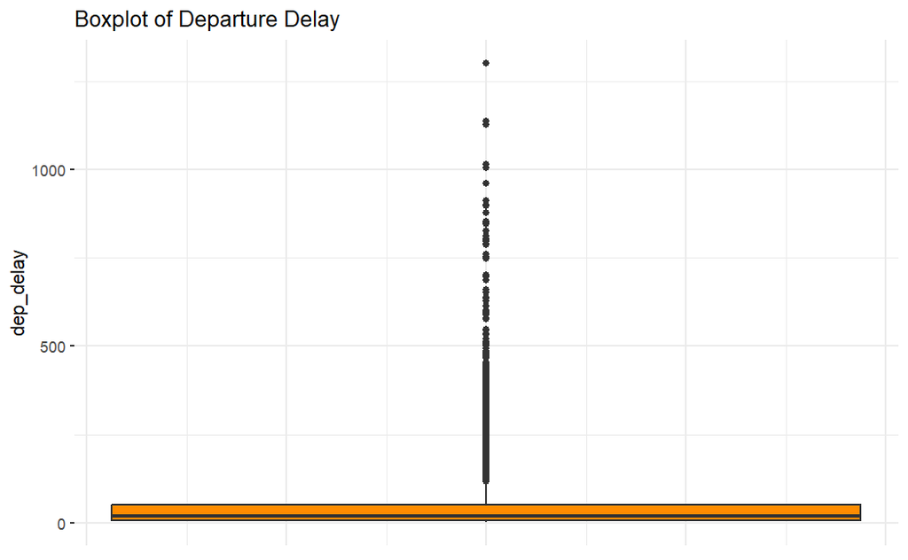

```r
ggplot(flights, aes(y = dep_delay)) +
  geom_boxplot(fill = "darkorange") +
  labs(y = "dep_delay") +
  ggtitle("Boxplot of Departure Delay") +
  theme_bw() +
  theme(panel.border = element_blank()) +
  theme(panel.border = element_blank()) +
  theme(axis.ticks.x = element_blank()) +
  theme(axis.text.x = element_blank())
```

### 4. A ggplot2 visualization, step by step

Data first:

```r
carriers <- flights |>
  dplyr::select(carrier) |>
  dplyr::group_by(carrier) |>
  dplyr::summarise(count = n()) |>
  dplyr::arrange(desc(count))

head(carriers, 10)
```

| carrier | count |
| --- | --- |
| UA | 27125 |
| EV | 22976 |
| B6 | 21372 |
| DL | 15186 |
| AA | 10105 |
| MQ | 7966 |
| 9E | 6980 |
| WN | 6535 |
| US | 4762 |
| VX | 2216 |

Take the following example of a bar plot:

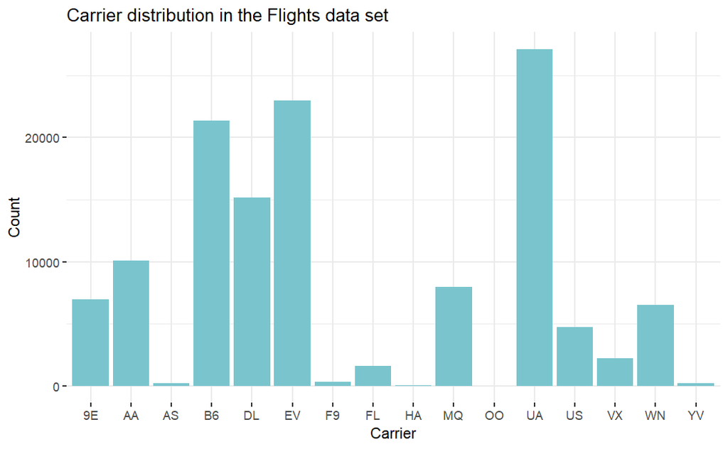

```r
ggplot(data = carriers,
       aes(x = carrier,
           y = count)
       ) +
  geom_bar(stat = 'identity', fill = "cadetblue3") +
  xlab('Carrier') +
  ylab('Count') +
  ggtitle('Carrier distribution in the Flights data set') +
  theme_bw() +
  theme(panel.border = element_blank())
```

Let’s go step by step to see how the structure of this chart is built.

First, without using geoms, we get only the “blueprint” of the chart: {ggplot2} recognizes which variables we are using and what are, broadly, their scales; it maps them to the horizontal and vertical axis.

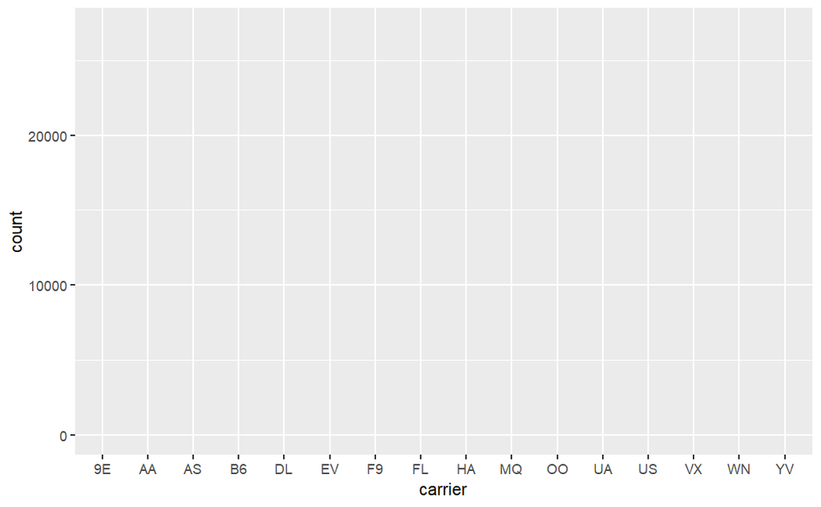

```r
ggplot(data = carriers,
       aes(x = carrier,
           y = count)
       )
```

Geoms are what {ggplot2} enables to understand how we want to visualize something. Geoms are its “verbs,” “predicates,” and they have a clearly defined semantics: we want a bar plot, or we want points, or lines, etc.

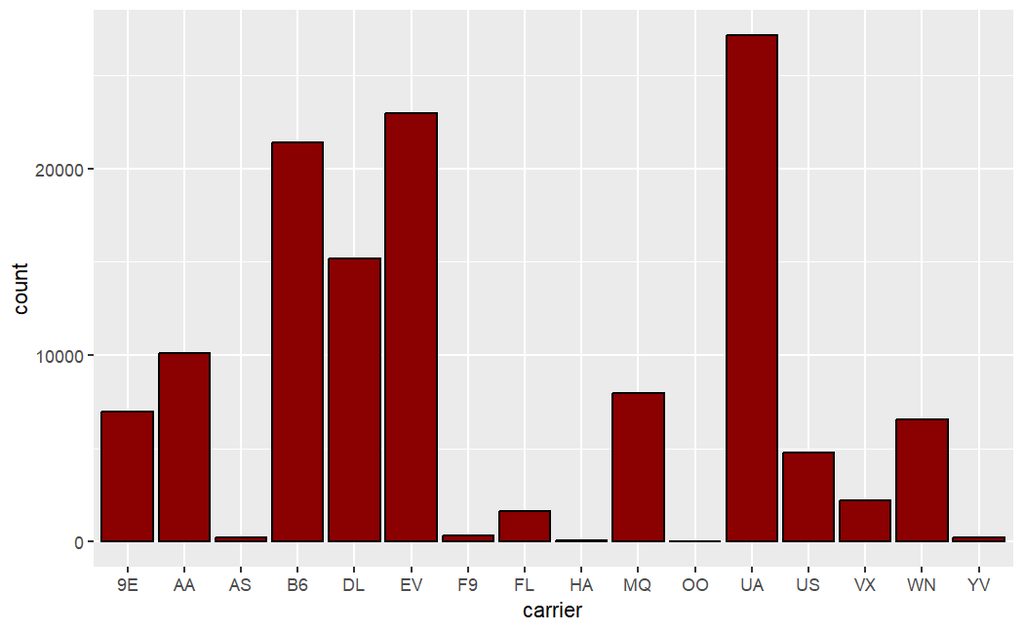

```r
ggplot(data = carriers,
       aes(x = carrier,
           y = count)
       ) +
  geom_bar(stat = 'identity',
           color = 'black',
           fill = 'darkred')
```

We add a title with the `ggtitle()` function and the axes labels with `xlab()` and `ylab()` :

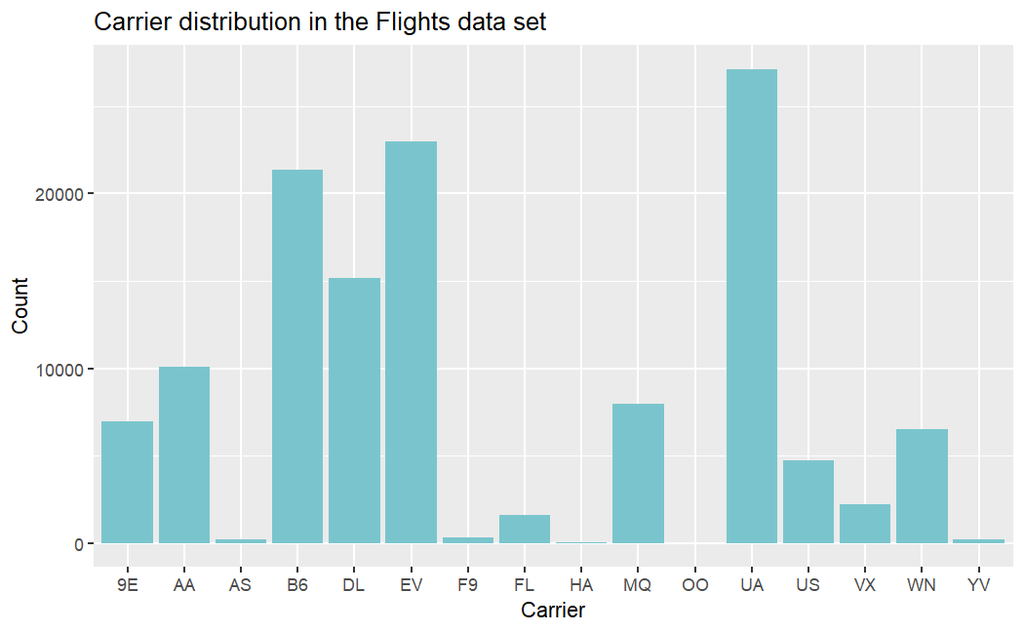

```r
ggplot(data = carriers,
       aes(x = carrier,
           y = count)
       ) +
  geom_bar(stat = 'identity',
           fill = "cadetblue3") +
  xlab('Carrier') +
  ylab('Count') +
  ggtitle('Carrier distribution in the Flights data set')
```

In the third step, we use the `theme()` function to fine-tune the elements of the chart precisely: while geoms describe how we want to present the data, in `theme()` we deal more with aesthetics and ergonomics.

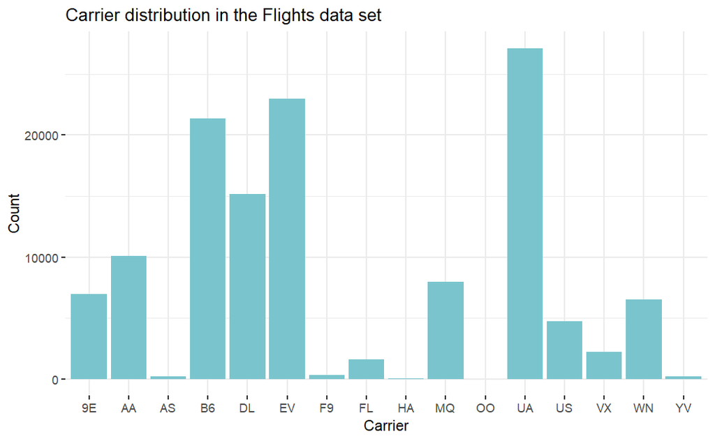

```r
ggplot(data = carriers,
       aes(x = carrier,
           y = count)
       ) +
  geom_bar(stat = 'identity', fill = "cadetblue3") +
  xlab('Carrier') +
  ylab('Count') +
  ggtitle('Carrier distribution in the Flights data set') +
  theme_bw() +
  theme(panel.border = element_blank())
```

And we fine-tune further, centering the title with theme():

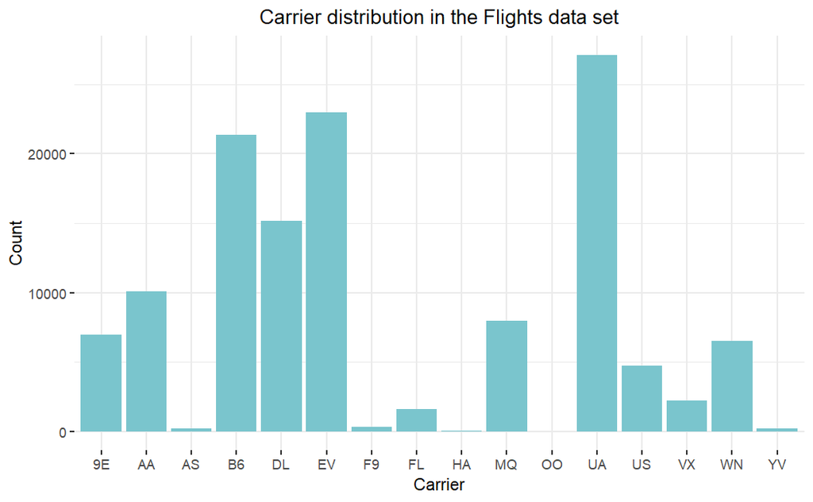

```r
ggplot(data = carriers,
       aes(x = carrier,
           y = count)
       ) +
  geom_bar(stat = 'identity', fill = "cadetblue3") +
  xlab('Carrier') +
  ylab('Count') +
  ggtitle('Carrier distribution in the Flights data set') +
  theme_bw() +
  theme(panel.border = element_blank()) +
  theme(plot.title = element_text(hjust = 0.5))
```

The documentation of `theme()` is rather important to master ggplot2: [Modify components of a theme](https://ggplot2.tidyverse.org/reference/theme.html).

Remember our boxplot of `dep_delay`? Let’s study departure delays across carriers now:

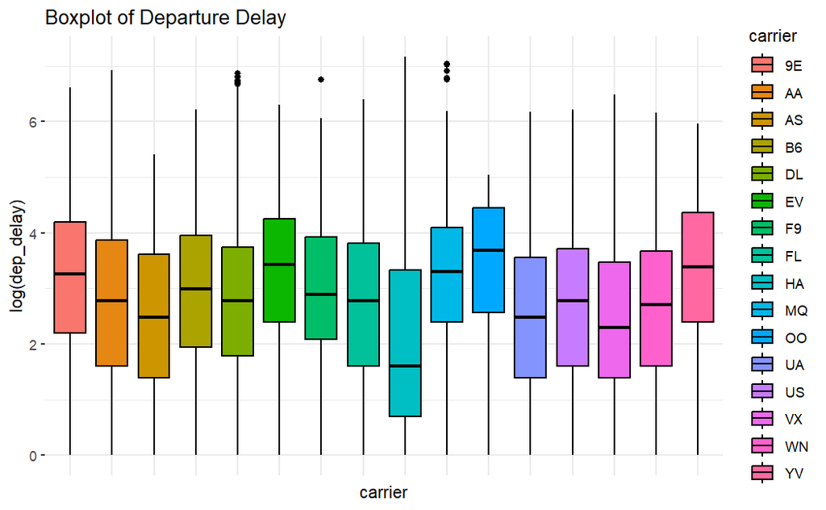

```r
ggplot(data = flights,
       aes(x = carrier,
           y = log(dep_delay),
           fill = carrier)) +
  geom_boxplot(color = "black") +
  labs(y = "log(dep_delay)") +
  ggtitle("Boxplot of Departure Delay") +
  theme_bw() +
  theme(panel.border = element_blank()) +
  theme(panel.border = element_blank()) +
  theme(axis.ticks.x = element_blank()) +
  theme(axis.text.x = element_blank())
```

### 5. A ggplot2 scatter plot

Scatter plots are a type of data visualization that show the relationship between two variables. Each point on the scatter plot represents an observation from the dataset, with its position determined by the values of these two variables.

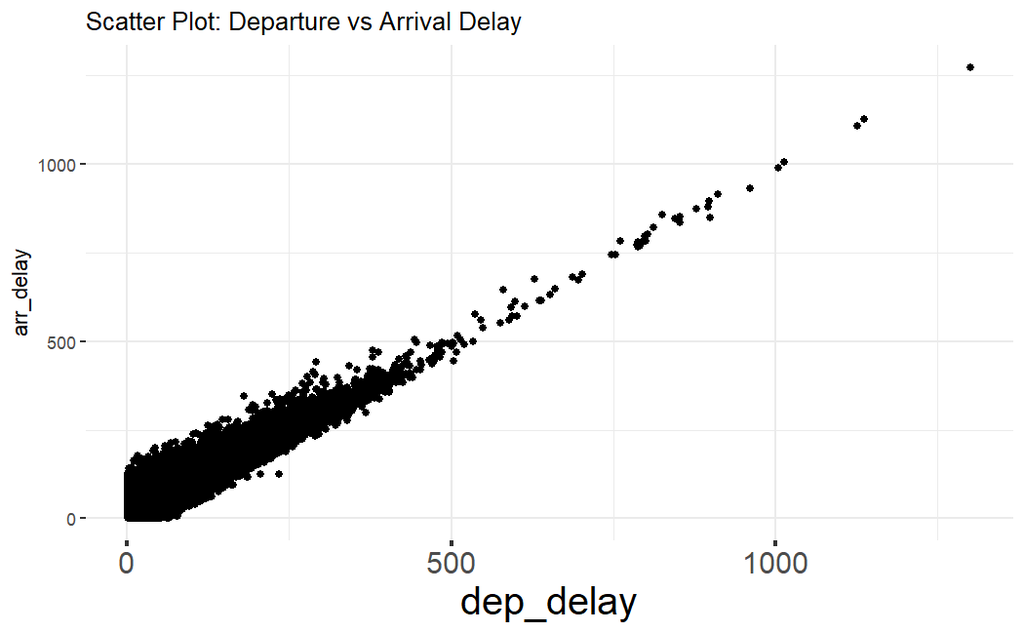

```r
flights <- flights[flights$arr_delay > 0, ]

ggplot(data = flights,
       aes(x = dep_delay,
           y = arr_delay)
       ) +
  geom_point() +
  theme_bw() +
  ggtitle("Scatter Plot: Departure vs Arrival Delay") +
  theme(panel.border = element_blank()) +
  theme(axis.ticks.x = element_line(linewidth = 1)) +
  theme(axis.text.x = element_text(size = 15)) +
  theme(axis.title.x = element_text(size = 20))
```

Let’s now map a third variable onto this scatter plot: `air_time`!

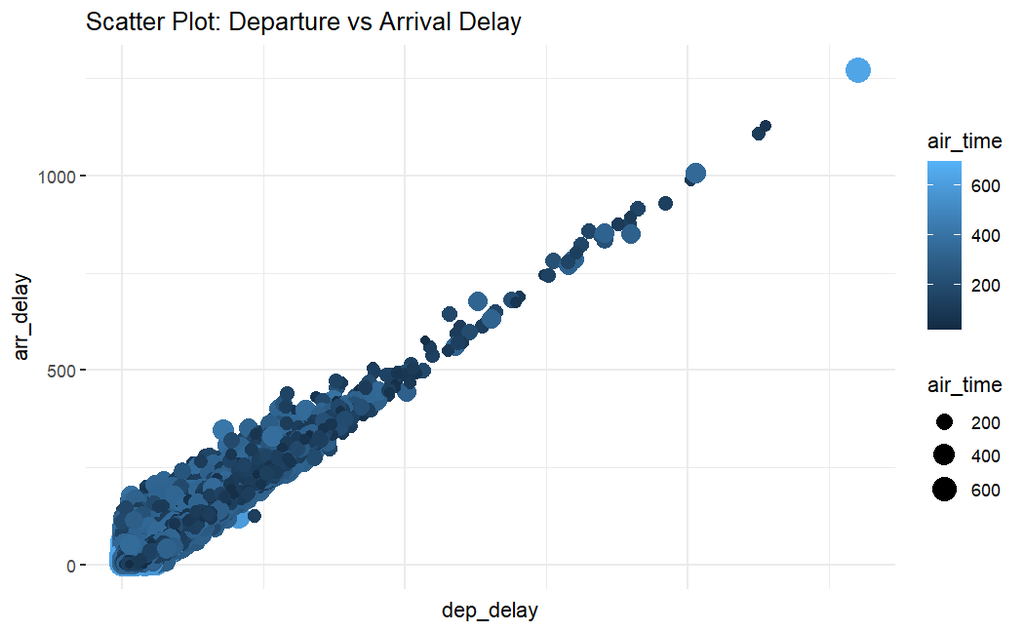

```r
ggplot(data = flights,
       aes(x = dep_delay,
           y = arr_delay,
           size = air_time,
           color = air_time)
       ) +
  geom_point() +
  theme_bw() +
  theme(panel.border = element_blank()) +
  ggtitle("Scatter Plot: Departure vs Arrival Delay") +
  theme_bw() +
  theme(panel.border = element_blank()) +
  theme(panel.border = element_blank()) +
  theme(axis.ticks.x = element_blank()) +
  theme(axis.text.x = element_blank())
```

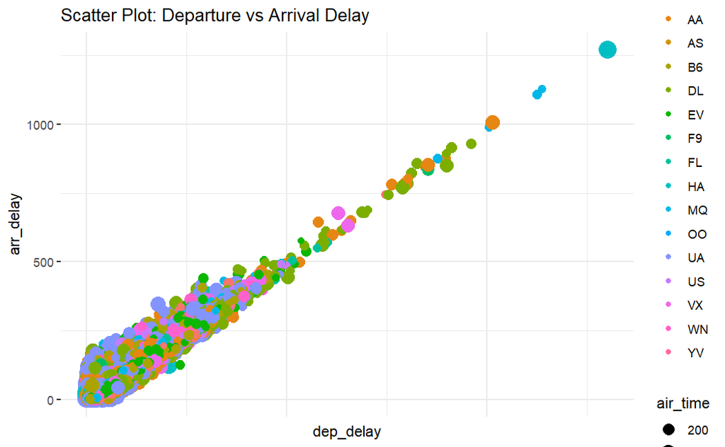

```r
ggplot(data = flights,
       aes(x = dep_delay,
           y = arr_delay,
           size = air_time,
           color = carrier)
       ) +
  geom_point() +
  theme_bw() +
  theme(panel.border = element_blank()) +
  ggtitle("Scatter Plot: Departure vs Arrival Delay") +
  theme_bw() +
  theme(panel.border = element_blank()) +
  theme(panel.border = element_blank()) +
  theme(axis.ticks.x = element_blank()) +
  theme(axis.text.x = element_blank())
```

Let’s now map a fourth variable onto this scatter plot: `distance`!

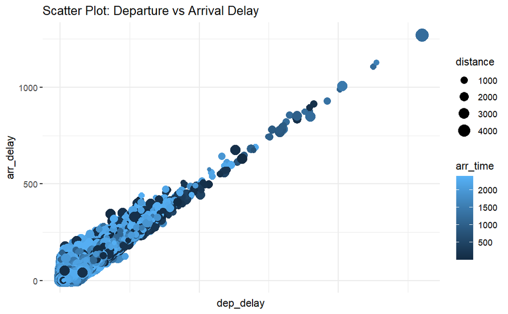

```r
ggplot(data = flights,
       aes(x = dep_delay,
           y = arr_delay,
           size = distance,
           color = arr_time)
       ) +
  geom_point() +
  theme_bw() +
  theme(panel.border = element_blank()) +
  ggtitle("Scatter Plot: Departure vs Arrival Delay") +
  theme_bw() +
  theme(panel.border = element_blank()) +
  theme(panel.border = element_blank()) +
  theme(axis.ticks.x = element_blank()) +
  theme(axis.text.x = element_blank())
```

And let’s use `facet_wrap()` to map a fifth variable: `carrier`.

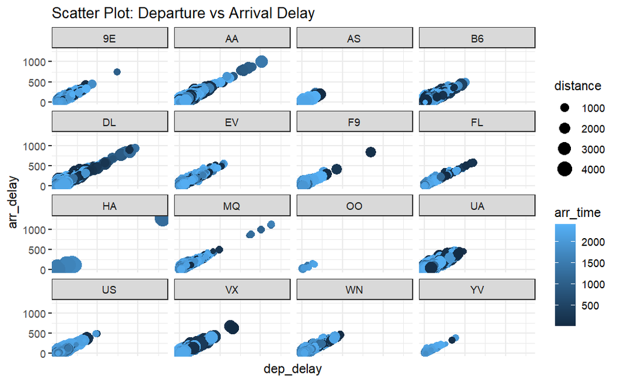

```r
ggplot(data = flights,
       aes(x = dep_delay,
           y = arr_delay,
           size = distance,
           color = arr_time)
       ) +
  geom_point() +
  facet_wrap(~carrier, ncol = 4) +
  theme_bw() +
  theme(panel.border = element_blank()) +
  ggtitle("Scatter Plot: Departure vs Arrival Delay") +
  theme_bw() +
  theme(panel.border = element_blank()) +
  theme(panel.border = element_blank()) +
  theme(axis.ticks.x = element_blank()) +
  theme(axis.text.x = element_blank())
```

### Further Readings

- Read [Visualize from R for Data Science 2d, Hadley Wickham & Garrett Grolemund: chapters 9, 10, and 11](https://r4ds.hadley.nz/)

### R Markdown

[R Markdown](https://rmarkdown.rstudio.com/) is what I have used to produce this beautiful Notebook. We will learn more about it near the end of the course, but if you already feel ready to dive deep, here’s a book: [R Markdown: The Definitive Guide, Yihui Xie, J. J. Allaire, Garrett Grolemunds.](https://bookdown.org/yihui/rmarkdown/)

Goran S. Milovanović

DataKolektiv, 2024.

contact: goran.milovanovic@datakolektiv.com

License: [GPLv3](http://www.gnu.org/licenses/gpl-3.0.txt) This Notebook is free software: you can redistribute it and/or modify it under the terms of the GNU General Public License as published by the Free Software Foundation, either version 3 of the License, or (at your option) any later version. This Notebook is distributed in the hope that it will be useful, but WITHOUT ANY WARRANTY; without even the implied warranty of MERCHANTABILITY or FITNESS FOR A PARTICULAR PURPOSE. See the GNU General Public License for more details. You should have received a copy of the GNU General Public License along with this Notebook. If not, see http://www.gnu.org/licenses/.